# Problem Set 4

Author

Charlie Tran

**For these questions, use your project data set that you have chosen for the Project assignment or any test data set other than those used in class lectures or labs.**

**This will be the first part of your semester project.**

**If you choose not to use Quarto or R Markdown, your results need to be similarly formatted to the output of a rendered Quarto or knitted R Markdown document. Readability and format matter.**

1. What is the source of your data set? (Where did you get it?)

Answer: A dataset from kaggle regarding details/characteristics of US real estate (https://www.kaggle.com/datasets/ahmedshahriarsakib/usa-real-estate-dataset) in several selected states but I will narrow the 900,000 data points to <4000 by only looking at real estate in NYC.

2. How did the source obtain the data? (Survey, experiment, observation/collection)

Answer: Data was collected from ‘www.realtor.com’ - A real estate listing website operated by the News Corp subsidiary Move, Inc. and based in Santa Clara, California. It is the second most visited real estate listing website in the United States as of 2021, with over 100 million monthly active users.

3. What are your two main variables of interest (x and y)? *If you are considering cause and effect, x is the cause and y is the effect*

Answer: How acre lot size (x) affects real estate price (y)

4. How many observations (n) are there? *You can use length() to count number or you can use View() to look at the data and look for the number of rows. You can also use as.numeric(length()) to create an object with the number of observations, n, for later use.*

**For both your x and y variables:**

n for x: 3375

n for y: 3375

```r
real_estate_nyc %>%
        count()
```

```
# A tibble: 1 × 1
      n
  <int>
1  3375
```

5. What is the median?

median of y: $1,775,000

```r
median(real_estate_nyc$acre_lot)
```

```
[1] 0.06
```

```r
median(real_estate_nyc$price)
```

```
[1] 1775000
```

6. What is the mean?

mean of x: 0.3976533 acres

mean of y: $3,799,384

```r
mean(real_estate_nyc$acre_lot)
```

```
[1] 0.3976533
```

```r
mean(real_estate_nyc$price)
```

```
[1] 3799384
```

7. What are the sample variance and sample standard deviation?

*Note: We will use sample variance for project data because in most cases your data sets are only a sample not the full population.*

sample variance of x: 115.7352

sample standard deviation of x: 10.75803

sample variance of y: 2.6595e+13

sample standard deviation of y: 5157034

```r
var(real_estate_nyc$acre_lot)
```

```
[1] 115.7352
```

```r
var(real_estate_nyc$price)
```

```
[1] 2.6595e+13
```

```r
sd(real_estate_nyc$acre_lot)
```

```
[1] 10.75803
```

```r
sd(real_estate_nyc$price)
```

```
[1] 5157034
```

8. What are the minimum and maximum?

x minimum: 0.01 x maximum: 625

y minimum: 319000 y maximum: 50,000,000

```r
min(real_estate_nyc$acre_lot)
```

```
[1] 0.01
```

```r
max(real_estate_nyc$acre_lot)
```

```
[1] 625
```

```r
min(real_estate_nyc$price)
```

```
[1] 319000
```

```r
max(real_estate_nyc$price)
```

```
[1] 5e+07
```

9. What are the first and third quartiles?

x first quartile: 0.04 acres x third quartile: 0.33 acres

y first quartile: $990,000 y third quartile: $4,047,500

```r
quantile(real_estate_nyc$acre_lot)
```

```
    0%    25%    50%    75%   100%
  0.01   0.04   0.06   0.33 625.00
```

```r
quantile(real_estate_nyc$price)
```

```
      0%      25%      50%      75%     100%
  319000   990000  1775000  4047500 50000000
```

10. Plot a histogram of the x variable. (2 points)

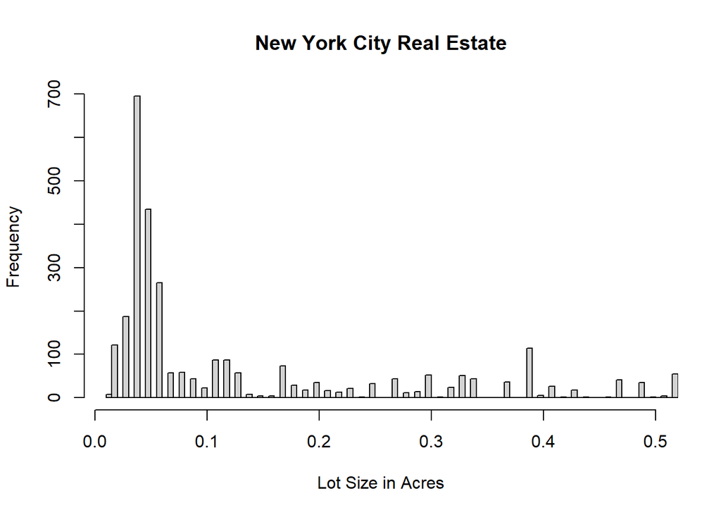

```r
hist(real_estate_nyc$acre_lot,
     breaks=100000,
     main="New York City Real Estate",
     xlab="Lot Size in Acres",
     xlim=c(0.01,0.5),
     )
```

11. Plot a histogram of the y variable. (2 points)

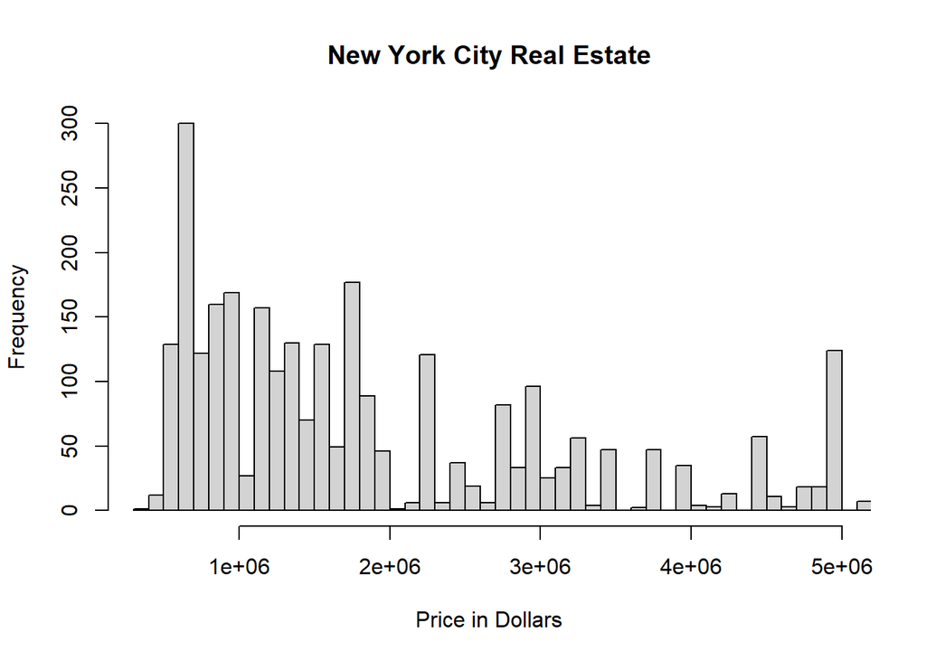

```r
hist(real_estate_nyc$price,
     breaks=500,
     main="New York City Real Estate",
     xlab="Price in Dollars",
     xlim=c(319000,5000000),
     )
```